# Análisis de un Dataset

## Notas del Dataset

### Significado de cada atributo

Otros:

34. **GDP:** Producto Interno Bruto
35. **Target:** Estado del estudiante

**NOTA: Los datos macroeconómicos, socioeconómicos y demográficos fueron capturados al momento de la inscripción del alumno. Los periodos académicos van desde el 2008/2009 hasta 2018/2019 tomando en cuenta estudiantes de diferentes áreas como agronomía, diseño, educación, enfermería, periodismo, tecnología, etc. El país de los alumnos es Portugal cuyo sistema de calificaciones se muestra a continuación:**

**1. 0-9.9: suspenso**

**2. 10-13.9: aprobado**

**3. 14-16.9: notable**

**4. 17-18.9: sobresaliente**

**5. 19-20: Matrícula de Honor**

### Codificación de cada atributo

#### Marital Status

1. Soltero
2. Casado
3. Viudo
4. Divorciado
5. Unión Libre
6. Separado Legalmente

#### Nacionalidad

1. Portugués
2. Alemán
3. Español
4. Italiano
5. Holandés
6. Inglés
7. Lituano
8. Angoleño
9. Cabo Verde
10. Guinea
11. Mozambiqueño
12. Santomean
13. Turco
14. Brasileño
15. Rumano
16. República de Moldova
17. Mexicano
18. Ucraniano
19. Ruso
20. Cubano
21. Colombiano

#### Método de Aplicación

1. 1st phase—general contingent
2. Ordinance No. 612/93
3. 1st phase—special contingent (Azores Island)
4. Holders of other higher courses
5. Ordinance No. 854-B/99
6. International student (bachelor)
7. 1st phase—special contingent (Madeira Island)
8. 2nd phase—general contingent
9. 3rd phase—general contingent
10. Ordinance No. 533-A/99, item b2) (Different Plan)
11. Ordinance No. 533-A/99, item b3 (Other Institution)
12. Over 23 years old
13. Transfer
14. Change in course
15. Technological specialization diploma holders
16. Change in institution/course
17. Short cycle diploma holders
18. Change in institution/course (International)

#### Curso

1. Biofuel Production Technologies
2. Animation and Multimedia Design
3. Social Service (evening attendance)
4. Agronomy
5. Communication Design
6. Veterinary Nursing
7. Informatics Engineering
8. Equiniculture
9. Management
10. Social Service
11. Tourism
12. Nursing
13. Oral Hygiene
14. Advertising and Marketing Management
15. Journalism and Communication
16. Basic Education
17. Management (evening attendance)

#### Grado de Estudios Previo

1. Secondary education
2. Higher education—bachelor’s degree
3. Higher education—degree
4. Higher education—master’s degree
5. Higher education—doctorate
6. Frequency of higher education
7. 12th year of schooling—not completed
8. 11th year of schooling—not completed
9. Other—11th year of schooling
10. 10th year of schooling
11. 10th year of schooling—not completed
12. Basic education 3rd cycle (9th/10th/11th year) or equivalent
13. Basic education 2nd cycle (6th/7th/8th year) or equivalent
14. Technological specialization course
15. Higher education—degree (1st cycle)
16. Professional higher technical course
17. Higher education—master’s degree (2nd cycle)

#### Grado de Estudios Padre y Madre

1. Secondary Education—12th Year of Schooling or Equivalent
2. Higher Education—bachelor’s degree
3. Higher Education—degree
4. Higher Education—master’s degree
5. Higher Education—doctorate
6. Frequency of Higher Education
7. 12th Year of Schooling—not completed
8. 11th Year of Schooling—not completed
9. 7th Year (Old)
10. Other—11th Year of Schooling
11. 2nd year complementary high school course
12. 10th Year of Schooling
13. General commerce course
14. Basic Education 3rd Cycle (9th/10th/11th Year) or Equivalent
15. Complementary High School Course
16. Technical-professional course
17. Complementary High School Course—not concluded
18. 7th year of schooling
19. 2nd cycle of the general high school course
20. 9th Year of Schooling—not completed
21. 8th year of schooling
22. General Course of Administration and Commerce
23. Supplementary Accounting and Administration
24. Unknown
25. Cannot read or write
26. Can read without having a 4th year of schooling
27. Basic education 1st cycle (4th/5th year) or equivalent
28. Basic Education 2nd Cycle (6th/7th/8th Year) or equivalent
29. Technological specialization course
30. Higher education—degree (1st cycle)
31. Specialized higher studies course
32. Professional higher technical course
33. Higher Education—master’s degree (2nd cycle)

#### Ocupación de Padre y Madre

1. Student
2. Representatives of the Legislative Power and Executive Bodies,

Directors, Directors and Executive Managers 3. Specialists in Intellectual and Scientific Activities 4. Intermediate Level Technicians and Professions 5. Administrative staff 6. Personal Services, Security and SafetyWorkers, and Sellers 7. Farmers and Skilled Workers in Agriculture, Fisheries, and Forestry 8. Skilled Workers in Industry, Construction, and Craftsmen 9. Installation and Machine Operators and Assembly Workers 10. Unskilled Workers 11. Armed Forces Professions 12. Other Situation; 13—(blank) 14. Armed Forces Officers 15. Armed Forces Sergeants 16. Other Armed Forces personnel 17. Directors of administrative and commercial services 18. Hotel, catering, trade, and other services directors 19. Specialists in the physical sciences, mathematics, engineering, and related techniques 20. Health professionals 21. Teachers 22. Specialists in finance, accounting, administrative organization, and public and commercial relations 23. Intermediate level science and engineering technicians and professions 24. Technicians and professionals of intermediate level of health 25. Intermediate level technicians from legal, social, sports, cultural, and similar services 26. Information and communication technology technicians 27. Office workers, secretaries in general, and data processing operators 28. Data, accounting, statistical, financial services, and registry-related operators 29. Other administrative support staff 30. Personal service workers 31. Sellers 32. Personal care workers and the like 33. Protection and security services personnel 34. Market-oriented farmers and skilled agricultural and animal production workers 35. Farmers, livestock keepers, fishermen, hunters and gatherers, and subsistence 36. Skilled construction workers and the like, except electricians 37. Skilled workers in metallurgy, metalworking, and similar 38. Skilled workers in electricity and electronics 39. Workers in food processing, woodworking, and clothing and other industries and crafts 40. Fixed plant and machine operators 41. Assembly workers 42. Vehicle drivers and mobile equipment operators 43. Unskilled workers in agriculture, animal production, and fisheries and forestry 44. Unskilled workers in extractive industry, construction, manufacturing, and transport 45. Meal preparation assistants 46. Street vendors (except food) and street service providers

#### Género

0. Femenino
1. Masculino

#### Asistencia Matutina/Vespertina

0. Vespertino
1. Matutino

#### Atributos con valores SÍ/NO

Valores:

0. NO
1. SÍ

Atributos:

1. Displaced
2. Educational Special Needs
3. Debtor
4. Tuitions fees up to date
5. Scholarship holder
6. International

## Análisis

```python
import numpy as np
import pandas as pd
import matplotlib
import matplotlib.pyplot as plt
```

Leer Dataset

```python
df = pd.read_csv('Dataset_Students_Success\dataset.csv')
df.head(5)
```

|  | Marital status | Application mode | Application order | Course | Daytime/evening attendance | Previous qualification | Nacionality | Mother's qualification | Father's qualification | Mother's occupation | ... | Curricular units 2nd sem (credited) | Curricular units 2nd sem (enrolled) | Curricular units 2nd sem (evaluations) | Curricular units 2nd sem (approved) | Curricular units 2nd sem (grade) | Curricular units 2nd sem (without evaluations) | Unemployment rate | Inflation rate | GDP | Target |
| --- | --- | --- | --- | --- | --- | --- | --- | --- | --- | --- | --- | --- | --- | --- | --- | --- | --- | --- | --- | --- | --- |
| 0 | 1 | 8 | 5 | 2 | 1 | 1 | 1 | 13 | 10 | 6 | ... | 0 | 0 | 0 | 0 | 0.000000 | 0 | 10.8 | 1.4 | 1.74 | Dropout |
| 1 | 1 | 6 | 1 | 11 | 1 | 1 | 1 | 1 | 3 | 4 | ... | 0 | 6 | 6 | 6 | 13.666667 | 0 | 13.9 | -0.3 | 0.79 | Graduate |
| 2 | 1 | 1 | 5 | 5 | 1 | 1 | 1 | 22 | 27 | 10 | ... | 0 | 6 | 0 | 0 | 0.000000 | 0 | 10.8 | 1.4 | 1.74 | Dropout |
| 3 | 1 | 8 | 2 | 15 | 1 | 1 | 1 | 23 | 27 | 6 | ... | 0 | 6 | 10 | 5 | 12.400000 | 0 | 9.4 | -0.8 | -3.12 | Graduate |
| 4 | 2 | 12 | 1 | 3 | 0 | 1 | 1 | 22 | 28 | 10 | ... | 0 | 6 | 6 | 6 | 13.000000 | 0 | 13.9 | -0.3 | 0.79 | Graduate |

5 rows × 35 columns

Número de Atributos e Instancias

```python
inst, atr = df.shape

print('El número de instancias es: ', inst)
print('El número de atributos es: ', atr)
```

```
El número de instancias es:  4424
El número de atributos es:  35
```

Número de Atributos con Datos Faltantes

```python
datos_faltantes = df.isnull().sum()
col_dat_falt = datos_faltantes[datos_faltantes > 0]

# print(datos_faltantes)
if col_dat_falt.empty:
    print('No hay datos faltantes')
else:
    print('Las columnas con datos faltantes son:  \n')
    print(col_dat_falt)
```

```
No hay datos faltantes
```

Mínimo, Máximo, Media y Desviación Estándar de cada atributo

```python
df_numeric = df.iloc[:,:-1] # Crear un nuevo dataframe sin la
                            # última columna que es categórica
medidas = {
    "min": df_numeric.min(),
    "max": df_numeric.max(),
    "media": df_numeric.mean(),
    "Desviación Estándar": df_numeric.std()
}
medidas = pd.DataFrame(medidas)
print(len(medidas))
medidas
```

```
34
```

|  | min | max | media | Desviación Estándar |
| --- | --- | --- | --- | --- |
| Marital status | 1.00 | 6.000000 | 1.178571 | 0.605747 |
| Application mode | 1.00 | 18.000000 | 6.886980 | 5.298964 |
| Application order | 0.00 | 9.000000 | 1.727848 | 1.313793 |
| Course | 1.00 | 17.000000 | 9.899186 | 4.331792 |
| Daytime/evening attendance | 0.00 | 1.000000 | 0.890823 | 0.311897 |
| Previous qualification | 1.00 | 17.000000 | 2.531420 | 3.963707 |
| Nacionality | 1.00 | 21.000000 | 1.254521 | 1.748447 |
| Mother's qualification | 1.00 | 29.000000 | 12.322107 | 9.026251 |
| Father's qualification | 1.00 | 34.000000 | 16.455244 | 11.044800 |
| Mother's occupation | 1.00 | 32.000000 | 7.317812 | 3.997828 |
| Father's occupation | 1.00 | 46.000000 | 7.819168 | 4.856692 |
| Displaced | 0.00 | 1.000000 | 0.548373 | 0.497711 |
| Educational special needs | 0.00 | 1.000000 | 0.011528 | 0.106760 |
| Debtor | 0.00 | 1.000000 | 0.113698 | 0.317480 |
| Tuition fees up to date | 0.00 | 1.000000 | 0.880651 | 0.324235 |
| Gender | 0.00 | 1.000000 | 0.351718 | 0.477560 |
| Scholarship holder | 0.00 | 1.000000 | 0.248418 | 0.432144 |
| Age at enrollment | 17.00 | 70.000000 | 23.265145 | 7.587816 |
| International | 0.00 | 1.000000 | 0.024864 | 0.155729 |
| Curricular units 1st sem (credited) | 0.00 | 20.000000 | 0.709991 | 2.360507 |
| Curricular units 1st sem (enrolled) | 0.00 | 26.000000 | 6.270570 | 2.480178 |
| Curricular units 1st sem (evaluations) | 0.00 | 45.000000 | 8.299051 | 4.179106 |
| Curricular units 1st sem (approved) | 0.00 | 26.000000 | 4.706600 | 3.094238 |
| Curricular units 1st sem (grade) | 0.00 | 18.875000 | 10.640822 | 4.843663 |
| Curricular units 1st sem (without evaluations) | 0.00 | 12.000000 | 0.137658 | 0.690880 |
| Curricular units 2nd sem (credited) | 0.00 | 19.000000 | 0.541817 | 1.918546 |
| Curricular units 2nd sem (enrolled) | 0.00 | 23.000000 | 6.232143 | 2.195951 |
| Curricular units 2nd sem (evaluations) | 0.00 | 33.000000 | 8.063291 | 3.947951 |
| Curricular units 2nd sem (approved) | 0.00 | 20.000000 | 4.435805 | 3.014764 |
| Curricular units 2nd sem (grade) | 0.00 | 18.571429 | 10.230206 | 5.210808 |
| Curricular units 2nd sem (without evaluations) | 0.00 | 12.000000 | 0.150316 | 0.753774 |
| Unemployment rate | 7.60 | 16.200000 | 11.566139 | 2.663850 |
| Inflation rate | -0.80 | 3.700000 | 1.228029 | 1.382711 |
| GDP | -4.06 | 3.510000 | 0.001969 | 2.269935 |

Dataframe de Correlación de Pearson

```python
df_pearson = df_numeric.corr()

df_pearson
```

|  | Marital status | Application mode | Application order | Course | Daytime/evening attendance | Previous qualification | Nacionality | Mother's qualification | Father's qualification | Mother's occupation | ... | Curricular units 1st sem (without evaluations) | Curricular units 2nd sem (credited) | Curricular units 2nd sem (enrolled) | Curricular units 2nd sem (evaluations) | Curricular units 2nd sem (approved) | Curricular units 2nd sem (grade) | Curricular units 2nd sem (without evaluations) | Unemployment rate | Inflation rate | GDP |
| --- | --- | --- | --- | --- | --- | --- | --- | --- | --- | --- | --- | --- | --- | --- | --- | --- | --- | --- | --- | --- | --- |
| Marital status | 1.000000 | 0.224855 | -0.125854 | 0.018925 | -0.274939 | 0.120925 | -0.020722 | 0.185522 | 0.128326 | 0.069734 | ... | 0.034711 | 0.062831 | 0.039026 | 0.022784 | -0.043739 | -0.071506 | 0.020426 | -0.020338 | 0.008761 | -0.027003 |
| Application mode | 0.224855 | 1.000000 | -0.246497 | -0.085116 | -0.268616 | 0.433028 | -0.001360 | 0.092867 | 0.072798 | 0.033489 | ... | 0.040255 | 0.228973 | 0.127461 | 0.164992 | -0.065203 | -0.104424 | 0.042009 | 0.091567 | -0.019613 | -0.014563 |
| Application order | -0.125854 | -0.246497 | 1.000000 | 0.118928 | 0.158657 | -0.199029 | -0.029385 | -0.061719 | -0.049936 | -0.046591 | ... | -0.031699 | -0.125815 | 0.028878 | -0.055089 | 0.071793 | 0.055517 | -0.015757 | -0.098419 | -0.011133 | 0.030201 |
| Course | 0.018925 | -0.085116 | 0.118928 | 1.000000 | -0.070232 | -0.158382 | -0.004761 | 0.058909 | 0.045659 | 0.029672 | ... | -0.060483 | -0.120390 | 0.185879 | 0.049236 | 0.120000 | 0.178997 | -0.013984 | -0.050116 | 0.028775 | -0.012518 |
| Daytime/evening attendance | -0.274939 | -0.268616 | 0.158657 | -0.070232 | 1.000000 | -0.103022 | 0.024433 | -0.195346 | -0.137769 | -0.037986 | ... | 0.045630 | -0.111953 | 0.000371 | 0.014610 | 0.034022 | 0.050493 | -0.004229 | 0.061974 | -0.024043 | 0.022929 |
| Previous qualification | 0.120925 | 0.433028 | -0.199029 | -0.158382 | -0.103022 | 1.000000 | -0.038997 | 0.018868 | 0.013152 | 0.006190 | ... | 0.018276 | 0.138463 | 0.056450 | 0.101501 | -0.037265 | -0.038765 | 0.024186 | 0.096914 | -0.056388 | 0.053968 |
| Nacionality | -0.020722 | -0.001360 | -0.029385 | -0.004761 | 0.024433 | -0.038997 | 1.000000 | -0.043847 | -0.088892 | 0.044123 | ... | 0.026203 | -0.000747 | -0.020103 | -0.018023 | -0.014142 | -0.005409 | -0.012052 | -0.006013 | -0.012331 | 0.044563 |
| Mother's qualification | 0.185522 | 0.092867 | -0.061719 | 0.058909 | -0.195346 | 0.018868 | -0.043847 | 1.000000 | 0.524529 | 0.295178 | ... | 0.003293 | 0.036986 | 0.033070 | 0.018874 | -0.013161 | -0.028472 | 0.020364 | -0.106107 | 0.056653 | -0.079664 |
| Father's qualification | 0.128326 | 0.072798 | -0.049936 | 0.045659 | -0.137769 | 0.013152 | -0.088892 | 0.524529 | 1.000000 | 0.207067 | ... | -0.017785 | 0.041695 | 0.023635 | 0.009471 | 0.006052 | -0.006508 | -0.008493 | -0.075417 | 0.056661 | -0.070200 |
| Mother's occupation | 0.069734 | 0.033489 | -0.046591 | 0.029672 | -0.037986 | 0.006190 | 0.044123 | 0.295178 | 0.207067 | 1.000000 | ... | -0.012569 | -0.002057 | 0.009287 | 0.011546 | 0.022309 | 0.035230 | -0.004903 | -0.011772 | 0.015014 | 0.091880 |
| Father's occupation | 0.024351 | 0.001253 | -0.029754 | 0.016489 | 0.000845 | 0.005381 | 0.024538 | 0.115989 | 0.184001 | 0.724007 | ... | -0.035299 | -0.014596 | 0.005548 | 0.000833 | 0.023651 | 0.036711 | -0.044760 | -0.026094 | 0.008047 | 0.125574 |
| Displaced | -0.234886 | -0.263079 | 0.332362 | 0.006142 | 0.251767 | -0.149356 | -0.010774 | -0.075864 | -0.055007 | -0.038521 | ... | -0.021671 | -0.091738 | -0.041823 | -0.038839 | 0.063698 | 0.069087 | -0.035959 | -0.130327 | -0.012385 | 0.062875 |
| Educational special needs | -0.028343 | -0.030868 | 0.025597 | -0.001886 | 0.031017 | -0.015015 | -0.002399 | -0.019808 | 0.000917 | -0.010175 | ... | -0.012324 | -0.021671 | -0.028777 | -0.010851 | -0.016315 | -0.012761 | -0.007491 | 0.046131 | 0.004396 | 0.012016 |
| Debtor | 0.034304 | 0.114348 | -0.072151 | -0.053149 | 0.006658 | 0.117447 | 0.070860 | 0.018776 | -0.006125 | 0.108151 | ... | 0.001812 | 0.025414 | -0.029436 | 0.024201 | -0.146977 | -0.139424 | 0.048552 | 0.021128 | -0.021888 | 0.075050 |
| Tuition fees up to date | -0.087158 | -0.127339 | 0.055891 | 0.029099 | 0.038799 | -0.095246 | -0.041721 | -0.022861 | -0.018033 | -0.004395 | ... | -0.049775 | 0.014204 | 0.085918 | 0.063482 | 0.291921 | 0.296480 | -0.071817 | 0.013460 | -0.000706 | -0.002768 |
| Gender | -0.014738 | 0.147226 | -0.089559 | -0.111383 | -0.012326 | 0.089952 | -0.025462 | -0.062374 | -0.073614 | -0.022324 | ... | -0.006302 | 0.018737 | -0.124227 | -0.041789 | -0.224266 | -0.199133 | 0.057223 | 0.022195 | 0.003556 | -0.008108 |
| Scholarship holder | -0.053765 | -0.152818 | 0.073709 | 0.051668 | 0.093912 | -0.085668 | -0.018468 | 0.048225 | 0.107134 | 0.092487 | ... | -0.057770 | -0.076480 | 0.026416 | -0.021410 | 0.202704 | 0.181227 | -0.048723 | 0.055152 | -0.031104 | 0.035650 |
| Age at enrollment | 0.522717 | 0.450700 | -0.271154 | -0.036929 | -0.462280 | 0.249821 | -0.008241 | 0.279921 | 0.190410 | 0.092257 | ... | 0.057470 | 0.207561 | 0.085914 | 0.056286 | -0.112052 | -0.173419 | 0.061654 | 0.025018 | 0.025377 | -0.064678 |
| International | -0.027905 | 0.005050 | -0.028801 | -0.004662 | 0.027973 | -0.033498 | 0.911724 | -0.038672 | -0.086503 | 0.041414 | ... | 0.031222 | 0.002573 | -0.013577 | -0.004399 | -0.010565 | 0.001460 | -0.010660 | -0.010015 | -0.009642 | 0.044389 |
| Curricular units 1st sem (credited) | 0.061209 | 0.238269 | -0.133354 | -0.140546 | -0.127466 | 0.159940 | 0.006604 | 0.041610 | 0.039259 | 0.002390 | ... | 0.116262 | 0.944811 | 0.644826 | 0.427845 | 0.490478 | 0.132971 | 0.055256 | 0.009778 | 0.023348 | -0.026513 |
| Curricular units 1st sem (enrolled) | 0.052107 | 0.159547 | -0.016808 | 0.112285 | -0.043056 | 0.080860 | -0.008011 | 0.050582 | 0.036564 | 0.014607 | ... | 0.129337 | 0.753747 | 0.942627 | 0.599567 | 0.673341 | 0.361959 | 0.069547 | 0.038404 | 0.036758 | -0.026262 |
| Curricular units 1st sem (evaluations) | 0.058030 | 0.219154 | -0.092156 | 0.025970 | -0.045889 | 0.129364 | 0.005640 | 0.041967 | 0.037225 | 0.019332 | ... | 0.241800 | 0.522187 | 0.611842 | 0.778863 | 0.442265 | 0.355036 | 0.134296 | 0.061545 | -0.006604 | -0.099761 |
| Curricular units 1st sem (approved) | -0.031027 | -0.023713 | 0.035580 | 0.077038 | 0.016935 | -0.005295 | 0.000935 | -0.010555 | 0.006787 | 0.015198 | ... | -0.013360 | 0.607661 | 0.733772 | 0.539934 | 0.904002 | 0.685560 | -0.053983 | 0.051286 | -0.007114 | 0.018459 |
| Curricular units 1st sem (grade) | -0.059811 | -0.106213 | 0.058308 | 0.179482 | 0.063974 | -0.034252 | 0.002578 | -0.034105 | -0.006245 | 0.016955 | ... | -0.071660 | 0.113937 | 0.406167 | 0.487236 | 0.673335 | 0.837170 | -0.066076 | 0.014821 | -0.033904 | 0.054801 |
| Curricular units 1st sem (without evaluations) | 0.034711 | 0.040255 | -0.031699 | -0.060483 | 0.045630 | 0.018276 | 0.026203 | 0.003293 | -0.017785 | -0.012569 | ... | 1.000000 | 0.117359 | 0.109924 | 0.144683 | -0.013070 | -0.061482 | 0.583261 | -0.045144 | -0.052534 | -0.144673 |
| Curricular units 2nd sem (credited) | 0.062831 | 0.228973 | -0.125815 | -0.120390 | -0.111953 | 0.138463 | -0.000747 | 0.036986 | 0.041695 | -0.002057 | ... | 0.117359 | 1.000000 | 0.676258 | 0.430978 | 0.519081 | 0.129770 | 0.070148 | 0.010580 | 0.014490 | -0.024491 |
| Curricular units 2nd sem (enrolled) | 0.039026 | 0.127461 | 0.028878 | 0.185879 | 0.000371 | 0.056450 | -0.020103 | 0.033070 | 0.023635 | 0.009287 | ... | 0.109924 | 0.676258 | 1.000000 | 0.604821 | 0.703258 | 0.395135 | 0.067697 | 0.064436 | 0.016844 | -0.007592 |
| Curricular units 2nd sem (evaluations) | 0.022784 | 0.164992 | -0.055089 | 0.049236 | 0.014610 | 0.101501 | -0.018023 | 0.018874 | 0.009471 | 0.011546 | ... | 0.144683 | 0.430978 | 0.604821 | 1.000000 | 0.463535 | 0.453394 | 0.144877 | 0.045808 | -0.012643 | -0.004854 |
| Curricular units 2nd sem (approved) | -0.043739 | -0.065203 | 0.071793 | 0.120000 | 0.034022 | -0.037265 | -0.014142 | -0.013161 | 0.006052 | 0.022309 | ... | -0.013070 | 0.519081 | 0.703258 | 0.463535 | 1.000000 | 0.760804 | -0.061567 | 0.048805 | -0.024566 | 0.022427 |
| Curricular units 2nd sem (grade) | -0.071506 | -0.104424 | 0.055517 | 0.178997 | 0.050493 | -0.038765 | -0.005409 | -0.028472 | -0.006508 | 0.035230 | ... | -0.061482 | 0.129770 | 0.395135 | 0.453394 | 0.760804 | 1.000000 | -0.079216 | 0.001462 | -0.038166 | 0.071269 |
| Curricular units 2nd sem (without evaluations) | 0.020426 | 0.042009 | -0.015757 | -0.013984 | -0.004229 | 0.024186 | -0.012052 | 0.020364 | -0.008493 | -0.004903 | ... | 0.583261 | 0.070148 | 0.067697 | 0.144877 | -0.061567 | -0.079216 | 1.000000 | -0.013960 | -0.034391 | -0.080292 |
| Unemployment rate | -0.020338 | 0.091567 | -0.098419 | -0.050116 | 0.061974 | 0.096914 | -0.006013 | -0.106107 | -0.075417 | -0.011772 | ... | -0.045144 | 0.010580 | 0.064436 | 0.045808 | 0.048805 | 0.001462 | -0.013960 | 1.000000 | -0.028885 | -0.335178 |
| Inflation rate | 0.008761 | -0.019613 | -0.011133 | 0.028775 | -0.024043 | -0.056388 | -0.012331 | 0.056653 | 0.056661 | 0.015014 | ... | -0.052534 | 0.014490 | 0.016844 | -0.012643 | -0.024566 | -0.038166 | -0.034391 | -0.028885 | 1.000000 | -0.112295 |
| GDP | -0.027003 | -0.014563 | 0.030201 | -0.012518 | 0.022929 | 0.053968 | 0.044563 | -0.079664 | -0.070200 | 0.091880 | ... | -0.144673 | -0.024491 | -0.007592 | -0.004854 | 0.022427 | 0.071269 | -0.080292 | -0.335178 | -0.112295 | 1.000000 |

34 rows × 34 columns

Calcular Valores Atípicos (outliers)

```python
dicc_len_outliers = {}

for column in df_numeric.columns:
    q1, q3 = df_numeric[column].quantile([0.25, 0.75]) # Calcular primer y tercer cuartil
    iqr = q3 - q1 # Calcular Rango Intercuartil

    # Filtrar valores
    outliers = df_numeric[(df_numeric[column] > q3 + 1.5*iqr) | (df_numeric[column] < q1 - 1.5*iqr)]

    # Agregar al diccionario
    dicc_len_outliers[column] = len(outliers)

print("OUTLIERS PARA CADA ATRIBUTO:", '\n')
print(dicc_len_outliers)
```

[output not shown]

## Graficación con Matplotlib

1. Gráfico de barras para visualizar el balance de las clases de acuerdo a la última columna 'Target'

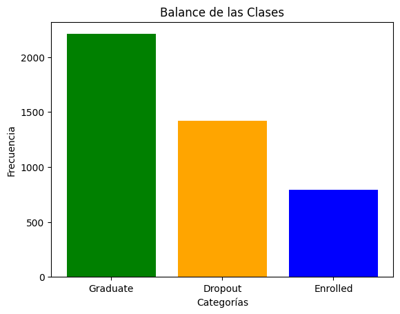

```python
colores = {"Graduate": 'green', "Dropout": 'orange', "Enrolled": 'blue'}
# Contar cantidad de veces en las que aparece cada clase
frecuencias = df['Target'].value_counts()

# Crear gráfica
plt.bar(frecuencias.index, frecuencias.values, color=[colores.get(x) for x in frecuencias.index])
plt.xlabel('Categorías')
plt.ylabel('Frecuencia')
plt.title('Balance de las Clases')
```

2. Gráfica de Barras Apiladas

```
[Text(0, 0, '')]
```

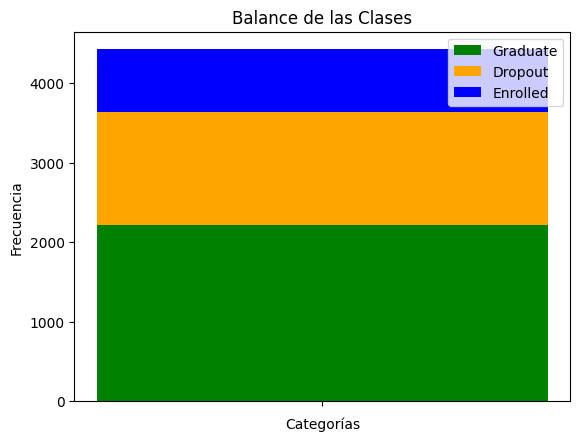

```python
plt.bar(frecuencias.index[0], frecuencias[0], color='g', label=frecuencias.index[0])
plt.bar(frecuencias.index[0], frecuencias[1], color = 'orange', bottom=frecuencias[0], label=frecuencias.index[1])
plt.bar(frecuencias.index[0], frecuencias[2], color = 'blue', bottom=frecuencias[0]+frecuencias[1], label=frecuencias.index[2])
plt.xlabel('Categorías')
plt.ylabel('Frecuencia')
plt.title('Balance de las Clases')
plt.legend()
plt.gca().set_xticklabels([]) # Quitar etiquetas de debajo del gráfico
```

3. Gráfico de Pastel

```
(-1.0999999999211363,
 1.0999999999962446,
 -1.0999998347850697,
 1.099999992095447)
```

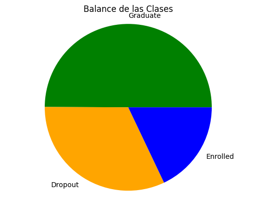

```python
plt.pie(frecuencias.values, labels=frecuencias.index, colors=[colores.get(x) for x in frecuencias.index])
plt.title('Balance de las Clases')
plt.axis('equal')
```

4. Mapa de calor (en base a la correlación de Pearson)

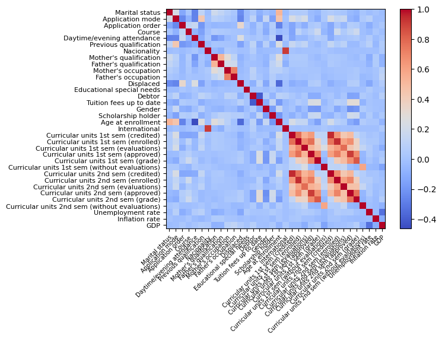

```python
figure = plt.figure()
ax = plt.subplot()
im = ax.imshow(df_pearson, cmap='coolwarm')

# Añadir etiquetas a los ejes y límites
ax.set_xticks(range(len(df_pearson)))
ax.set_yticks(range(len(df_pearson)))
ax.set_xticklabels(df_pearson.columns, fontsize=7)
ax.set_yticklabels(df_pearson.columns, fontsize=8)

# Rotar las etiquetas del eje X para que quepan en el gráfico
plt.setp(ax.get_xticklabels(), rotation=45, ha='right', rotation_mode='anchor')

# Añadir una barra de colores para mostrar la intensidad de la correlación
figure.colorbar(im)
```

5. Histograma para visualizar la distribución de los datos

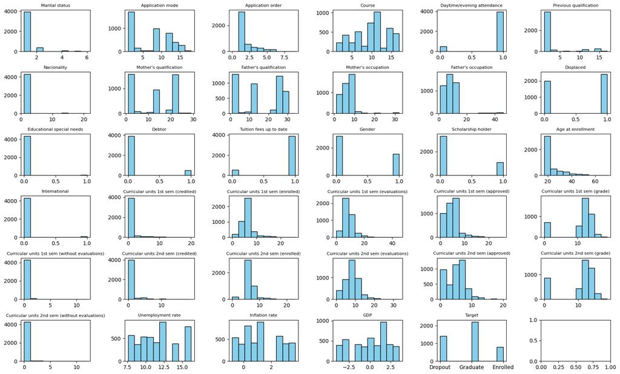

```python
# Crear histograma
fig, axs = plt.subplots(nrows=6, ncols=6, figsize=(20, 12))
fig.subplots_adjust(hspace=0.5, wspace=0.5)

# Crear histogramas para cada columna
for i, col in enumerate(df.columns):
    ax = axs[i//6, i%6] # seleccionar el subplot correspondiente
    ax.hist(df[col], bins=10, color='skyblue', edgecolor='black')
    ax.set_title(col, fontsize=8)
```

6. Histograma con Líneas

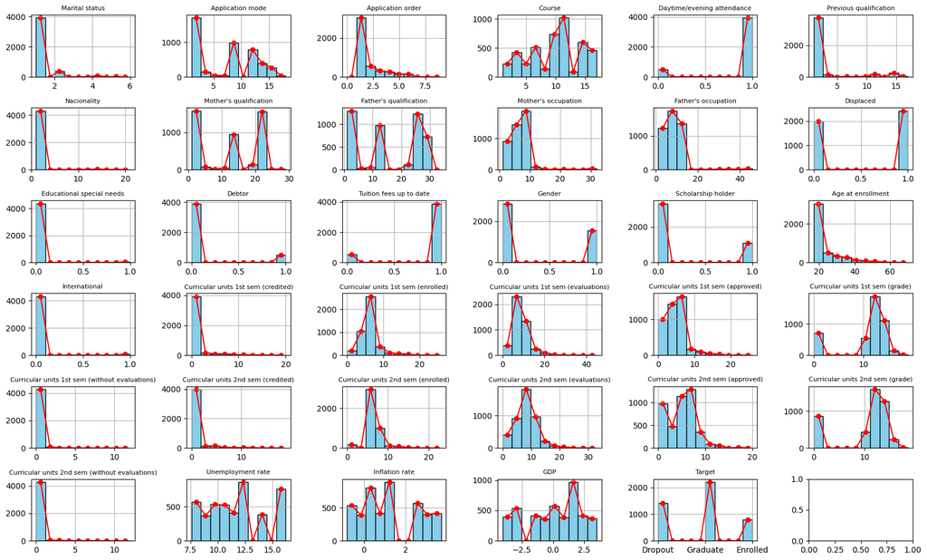

```python
fig, axs = plt.subplots(nrows=6, ncols=6, figsize=(20, 12))
fig.subplots_adjust(hspace=0.5, wspace=0.5)

for i, col in enumerate(df.columns):
    ax = axs[i//6, i%6]
    n, bins, patches = ax.hist(df[col], bins=10, color='skyblue', edgecolor='black')
    x = bins[:-1] + (bins[1] - bins[0]) / 2  # calcular el centro de cada barra
    y = n  # usar la frecuencia como altura del punto
    ax.scatter(x, y, c='red', marker='o', s=30)  # agregar los puntos
    ax.plot(x, y, c='red')  # unir los puntos con una línea
    ax.set_title(col, fontsize=8)
    ax.grid()
```

7. Gráfico de Densidad

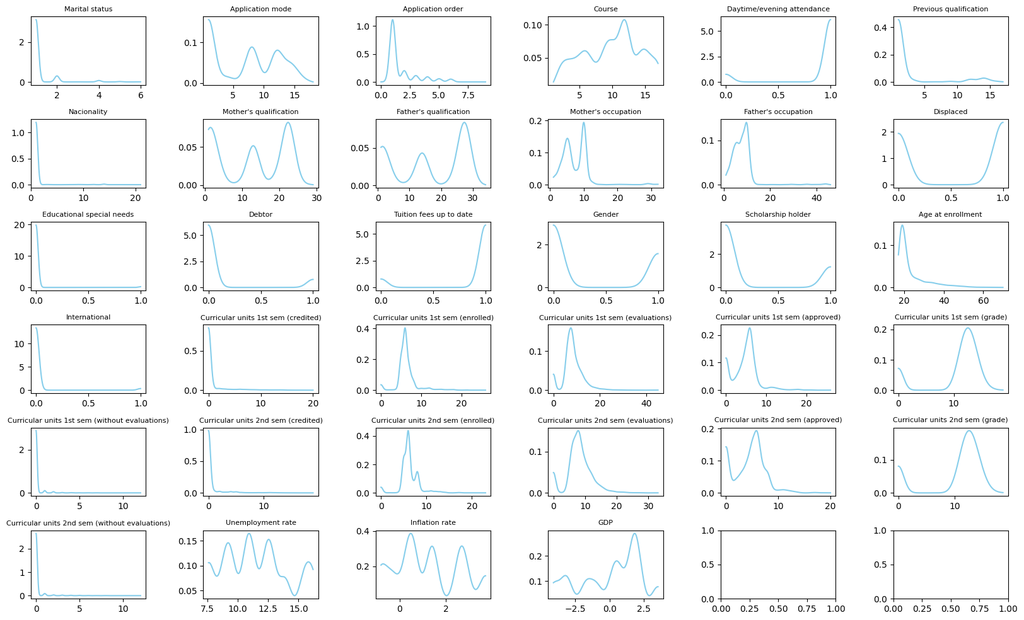

```python
from scipy.stats import kde

# Crear gráficas de densidad para cada columna
fig, axs = plt.subplots(nrows=6, ncols=6, figsize=(20, 12))
fig.subplots_adjust(hspace=0.5, wspace=0.5)

for i, col in enumerate(df_numeric.columns):
    ax = axs[i//6, i%6] # seleccionar el subplot correspondiente
    density = kde.gaussian_kde(df_numeric[col])
    x = np.linspace(df_numeric[col].min(), df_numeric[col].max(), 1000)
    ax.plot(x, density(x), color='skyblue')
    ax.set_title(col, fontsize=8)
```

8. Boxplot

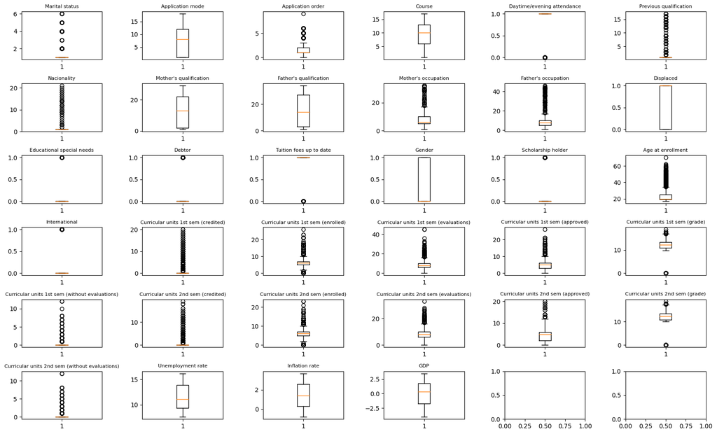

```python
# Crear histograma
fig, axs = plt.subplots(nrows=6, ncols=6, figsize=(20, 12))
fig.subplots_adjust(hspace=0.5, wspace=0.5)

# Crear boxplot para cada columna
for i, col in enumerate(df_numeric.columns):
    ax = axs[i//6, i%6] # seleccionar el subplot correspondiente
    ax.boxplot(df_numeric[col])
    ax.set_title(col, fontsize=8)
```

9. Gráfico de Violín

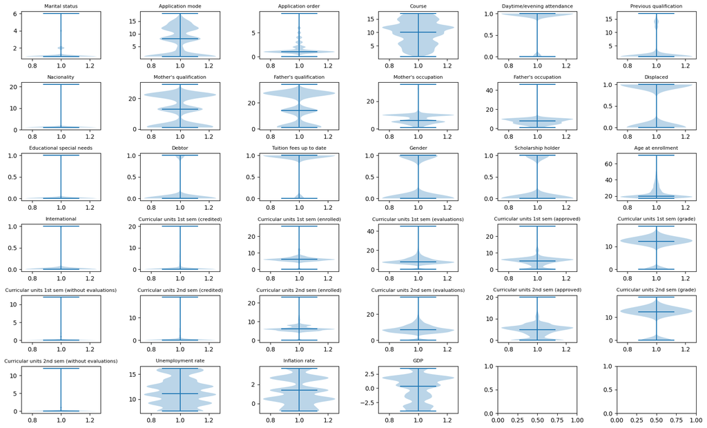

```python
# Crear gráfico de violín
fig, axs = plt.subplots(nrows=6, ncols=6, figsize=(20, 12))
fig.subplots_adjust(hspace=0.5, wspace=0.5)

# Crear violín para cada columna
for i, col in enumerate(df_numeric.columns):
    ax = axs[i//6, i%6] # seleccionar el subplot correspondiente
    ax.violinplot(df_numeric[col], showmedians=True)
    ax.set_title(col, fontsize=8)
```

10. Gráfico de Dispersión

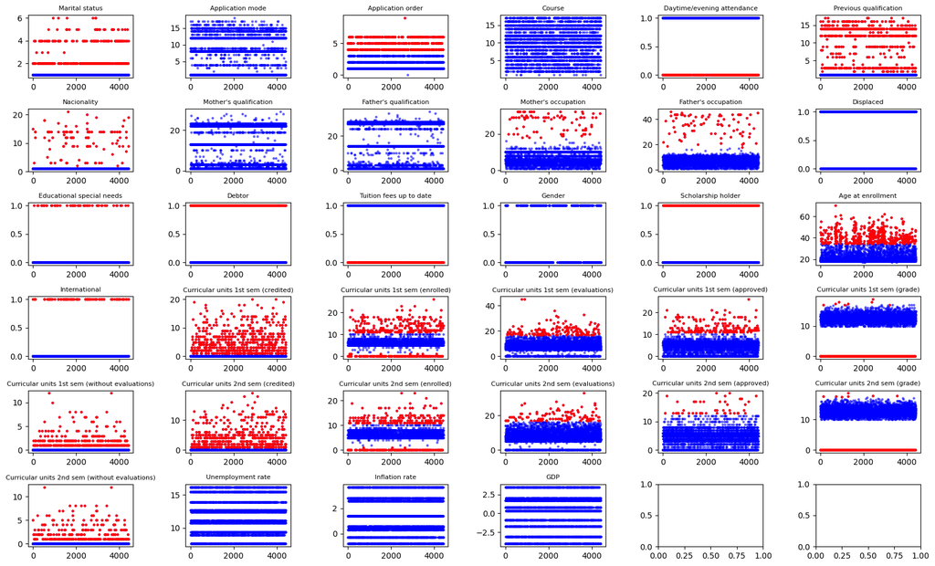

```python
# Crear histograma
fig, axs = plt.subplots(nrows=6, ncols=6, figsize=(20, 12))
fig.subplots_adjust(hspace=0.5, wspace=0.5)

# Crear gráfica de dispersión para cada columna
for i, col in enumerate(df_numeric.columns):
    ax = axs[i//6, i%6] # seleccionar el subplot correspondiente
    ax.scatter(range(len(df_numeric)), df_numeric[col], s=5, alpha=0.5, color='blue')
    # ax.scatter(range(len(dicc_outliers[col])), dicc_outliers[col], color='red', s=1)
    ax.set_title(col, fontsize=8)
    ax.set_xlabel('')
    ax.set_ylabel('')

    # Marcar los outliers con un color diferente
    q1 = df_numeric[col].quantile(0.25)
    q3 = df_numeric[col].quantile(0.75)
    iqr = q3 - q1
    outliers = df[(df[col] < q1 - 1.5*iqr) | (df[col] > q3 + 1.5*iqr)][col]
    ax.scatter(outliers.index, outliers, color='red', s=5)
```

## Graficación con Plotly

1. Gráfico de Barras

```python
import plotly.graph_objects as go

colores = {"Graduate": 'green', "Dropout": 'orange', "Enrolled": 'blue'}
frecuencias = df['Target'].value_counts()

fig = go.Figure(go.Bar(x=frecuencias.index, y=frecuencias.values, marker_color=[colores.get(x) for x in frecuencias.index]))
fig.update_layout(title='Balance de las Clases', xaxis_title='Categorías', yaxis_title='Frecuencia')
```

2. Gráfica de Barras Apiladas

```python
# Obtener las frecuencias de cada subcategoría
graduados = df[df['Target'] == 'Graduate']['Target'].value_counts()
dropouts = df[df['Target'] == 'Dropout']['Target'].value_counts()
enrolled = df[df['Target'] == 'Enrolled']['Target'].value_counts()

# Crear la figura con las barras apiladas
fig = go.Figure()
fig.add_trace(go.Bar(x=graduados.index, y=graduados.values, name='Graduate', marker_color=colores['Graduate']))
fig.add_trace(go.Bar(x=graduados.index, y=dropouts.values, name='Dropout', marker_color=colores['Dropout']))
fig.add_trace(go.Bar(x=graduados.index, y=enrolled.values, name='Enrolled', marker_color=colores['Enrolled']))
fig.update_layout(title='Balance de las Clases', xaxis_title='Categorías', yaxis_title='Frecuencia', barmode='stack')
```

3. Gráfica de Pastel

```python
# Crear gráfica de pastel
fig = go.Figure(data=[go.Pie(labels=frecuencias.index, values=frecuencias.values, marker=dict(colors=[colores.get(x) for x in frecuencias.index]))])

# Configurar diseño de la gráfica
fig.update_layout(title='Balance de las Clases')
```

4. Mapa de Calor

```python
import plotly.express as px

fig = px.imshow(df_pearson,
                x=df_pearson.columns,
                y=df_pearson.columns,
                color_continuous_scale='RdBu',
                zmin=-1,
                zmax=1)

fig.update_layout(width=800, height=800, title="Matriz de correlación")

fig.show()
```

5. Histograma

```python
from plotly.subplots import make_subplots

fig = make_subplots(rows=6, cols=6, subplot_titles=df_numeric.columns)

for i, col in enumerate(df_numeric.columns):
    ax = i//6 + 1
    ay = i%6 + 1
    fig.add_trace(go.Histogram(x=df_numeric[col], name=col), ax, ay)

fig.update_layout(title='Histogramas de cada columna', height=1000, width=2000, showlegend=False)
```

6. Histograma con Densidad

```python
import plotly.figure_factory as ff
import numpy as np

hist_data = [df_numeric['Course']]
group_labels = ['Course'] # name of the dataset

fig = ff.create_distplot(hist_data, group_labels, colors=['rgb(0,125,125)'], show_rug=False)
fig.update_layout(title='Course', showlegend=False)
```

7. Gráfico de Densidad

```python
import plotly.figure_factory as ff
import numpy as np

hist_data = [df_numeric['Curricular units 1st sem (approved)']]
group_labels = ['Curricular units 1st sem (approved)'] # name of the dataset

fig = ff.create_distplot(hist_data, group_labels, colors=['rgb(255,0,0)'], show_hist=False, show_rug=False)
fig.add_trace(go.Scatter(x=fig['data'][0]['x'], y=fig['data'][0]['y'], fill='tozeroy', fillcolor='rgba(255,0,0,0.2)', line_color='rgba(255,0,0,0)'))
fig.update_layout(title='Curricular units 1st sem (approved)', showlegend=False)
```

8. Gráfico de Violín

```python
import plotly.graph_objs as go

# Crear gráficas de densidad para cada columna
fig = make_subplots(rows=6, cols=6, subplot_titles=df_numeric.columns)

for i, col in enumerate(df_numeric.columns):
    ax = (i // 6) + 1
    ay = (i % 6) + 1
    fig.add_trace(go.Violin(y=df_numeric[col], name=col, box_visible=True), ax, ay)

fig.update_layout(title='Gráficos de densidad de cada columna', height=1000, width=2000, showlegend=False)
```

9. Boxplot

```python
import plotly.graph_objs as go

# Crear gráficas de densidad para cada columna
fig = make_subplots(rows=6, cols=6, subplot_titles=df_numeric.columns)

for i, col in enumerate(df_numeric.columns):
    ax = (i // 6) + 1
    ay = (i % 6) + 1
    fig.add_trace(go.Box(y=df_numeric[col], name=col), ax, ay)

fig.update_layout(title='Gráficos de densidad de cada columna', height=1000, width=2000, showlegend=False)
```

```python
# import plotly.graph_objects as go

# fig = make_subplots(rows=6, cols=6, subplot_titles=df_numeric.columns)

# for i, col in enumerate(df_numeric.columns):
#     ax = i//6 + 1
#     ay = i%6 + 1
#     fig.add_trace(go.Scatter(y=df_numeric[col], mode='markers', name=col), ax, ay)
#     fig.update_traces(histnorm='probability density', selector=dict(type='histogram'))

# fig.update_layout(title='Densidad de cada columna', height=1000, width=2000, showlegend=False)
```